# Publication figure report

Author

Affiliation

none

manual

**Important**

A manual command generated this report without an LLM model. No separate human scientific review is part of this fixed recipe. The report records the selected recipe and does not claim a new statistical method.

## Figure

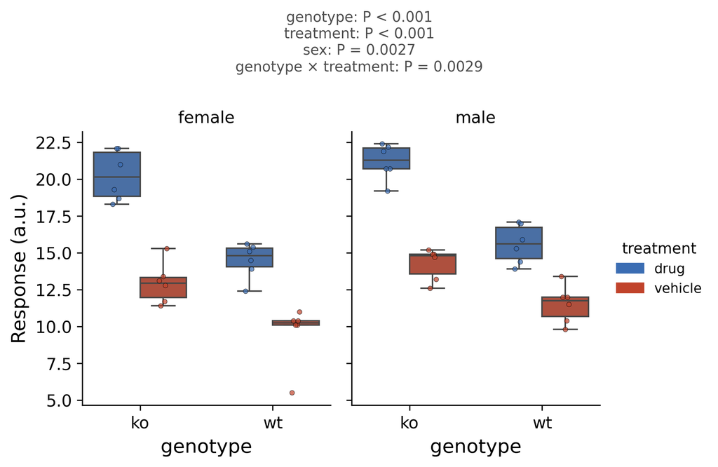

Publication figure

## Statistical results

| effect | df1 | df2 | statistic | p_value | effect_size | effect_size_name | significant | residual_shapiro_p |
| --- | --- | --- | --- | --- | --- | --- | --- | --- |
| genotype | 1 | 40 | 111.2970333218272 | 4.034754681085697e-13 | 0.7356194029600359 | partial eta squared | TRUE | 0.05005220875977767 |
| treatment | 1 | 40 | 197.0118992019824 | 4.8090104894002654e-17 | 0.8312321021236497 | partial eta squared | TRUE | 0.05005220875977767 |
| sex | 1 | 40 | 10.202550409161775 | 0.0027343973072734788 | 0.20322773098196714 | partial eta squared | TRUE | 0.05005220875977767 |
| genotype:treatment | 1 | 40 | 10.074217718845782 | 0.002890120529548012 | 0.2011857234677134 | partial eta squared | TRUE | 0.05005220875977767 |
| genotype:sex | 1 | 40 | 0.2437711941844083 | 0.624195816399937 | 0.006057364579680232 | partial eta squared | FALSE | 0.05005220875977767 |
| treatment:sex | 1 | 40 | 0.5118078258574037 | 0.47851267962764477 | 0.012633546941608786 | partial eta squared | FALSE | 0.05005220875977767 |
| genotype:treatment:sex | 1 | 40 | 0.07401466079151847 | 0.7869780803081738 | 0.0018469489872182567 | partial eta squared | FALSE | 0.05005220875977767 |

## Methods

Response (a.u.) was analyzed by a 3-way ANOVA (Type II sums of squares) with factors genotype, treatment, sex. Effects tested: genotype (F(1, 40) = 111.30, P < 0.001); treatment (F(1, 40) = 197.01, P < 0.001); sex (F(1, 40) = 10.20, P = 0.0027); genotype x treatment (F(1, 40) = 10.07, P = 0.0029); genotype x sex (F(1, 40) = 0.24, P = 0.62); treatment x sex (F(1, 40) = 0.51, P = 0.48); genotype x treatment x sex (F(1, 40) = 0.07, P = 0.79). Effect sizes are partial eta squared. Significance was set at P < 0.05. Analyses were performed in Python 3.10.12 with statsmodels 0.15.0; figures were produced with seaborn 0.13.2. (The Python engine uses parametric ANOVA only; the aligned rank transform is R-only.)

## Plot configuration

The complete plot configuration is in `plot_config.yaml`.

## Provenance

[output not shown]

The report source reads only files in this bundle.